# Deep Learning for Mortality Forecasting: A Comparative Study of LSTM Variants

Author

Mortality Forecasting Project

Published

27 June 2026

Abstract

# 1 Introduction

The question of how long people will live carries consequences that extend far beyond the domain of academic demography. Pension funds, life insurers, social security administrators, and government treasuries all make multi-decade financial commitments whose solvency depends critically on the accuracy of mortality forecasts. An underestimate of life expectancy by even a single year can translate into billions of dollars of unfunded liability for a national pension scheme; an overestimate distorts insurance pricing and misallocates public health resources. As populations across the developed world continue to age at historically unprecedented rates, the demand for mortality forecasting methods that are both accurate and robust has never been more acute.

The dominant framework for age-specific mortality forecasting over the past three decades remains the model introduced by Lee and Carter (1992). The Lee-Carter model decomposes the log central death rate $\ln m(x, t)$ according to the bilinear structure

$$\ln m(x, t) = \alpha_x + \beta_x \kappa_t + \varepsilon_{x,t},$$

where $\alpha_x$ captures the average age profile of mortality, $\kappa_t$ is a latent period index governing the overall level of mortality through time, $\beta_x$ quantifies the sensitivity of each age group to changes in $\kappa_t$, and $\varepsilon_{x,t}$ is a zero-mean error term. Mortality projections are then obtained by extrapolating $\kappa_t$ as a random walk with drift. The Lee-Carter model’s enduring appeal stems from its parsimony and interpretability: it reduces a high-dimensional mortality surface to a single stochastic index, and the biological meaning of its components is transparent to practitioners in insurance and public policy alike.

Nevertheless, the Lee-Carter framework rests on assumptions that have attracted sustained critical attention. Most importantly, the age-sensitivity loadings $\beta_x$ are assumed to be constant over the entire estimation horizon, so that all age groups respond proportionally to the same period shock. Empirical evidence from multiple national datasets suggests that the relative pace of improvement has shifted considerably across age groups over recent decades, violating this fixed-interaction assumption. Furthermore, the model imposes a linear drift on $\kappa_t$, rendering it poorly equipped to capture structural breaks or accelerations in mortality improvement — such as those associated with the cardiovascular revolution of the 1970s and 1980s — without ad hoc intervention. These limitations have motivated a substantial literature exploring generalisations of the Lee-Carter framework, including the age-period-cohort extensions of Renshaw and Haberman (2006) and the multi-population models of Li and Lee (2005).

A parallel strand of research has drawn on developments in deep learning to ask whether neural networks can address the shortcomings of classical actuarial models. Long Short-Term Memory (LSTM) networks, introduced by Hochreiter and Schmidhuber (1997), are a class of recurrent neural network architectures specifically designed to capture long-range temporal dependencies through gated memory cells that regulate the flow of information across time steps. Unlike autoregressive statistical models, LSTMs impose no parametric assumptions on the temporal dynamics of the series being modelled, can learn non-linear relationships between predictors and outcomes, and can in principle process the full multivariate mortality surface jointly, exploiting correlations across age groups that univariate methods discard.

Several recent contributions have assessed the applicability of these architectures to mortality data. Richman and Schreck (2021) provided an influential early demonstration, replacing the random walk extrapolation of $\kappa_t$ in the Lee-Carter model with an LSTM, yielding what the present paper refers to as the kt-LSTM approach. Their results on multi-country Human Mortality Database (HMD) data indicated that recurrent networks could improve out-of-sample accuracy relative to the classical random walk specification. Perla et al. (2021) extended this line of inquiry by applying both convolutional and recurrent architectures directly to the matrix of log death rates drawn from the HMD, reporting competitive performance relative to established actuarial benchmarks across a broad cross-section of countries. Nigri, Levantesi, and Marino (2021) proposed a hybrid strategy in which a neural network augments the Lee-Carter decomposition, learning residual structure that the bilinear model leaves unexplained. Collectively, these contributions demonstrate that deep learning methods can achieve competitive or improved accuracy relative to classical benchmarks in mortality forecasting, with gains most evident when training on rich multi-country or multi-population datasets. Booth et al. (2006) provided an important reference point for this discussion by benchmarking a range of Lee-Carter variants across ten countries, establishing empirical baselines against which subsequent methodological proposals were evaluated.

A notable gap in this literature concerns the single-country, data-constrained setting. The favourable results reported for LSTMs have almost uniformly been obtained in regimes where the training corpus is large — spanning many countries or very long historical series — providing the network with the volume of observations necessary to estimate its substantial parameter count. It remains unclear whether these advantages persist when the practitioner is restricted to the mortality history of a single country over a span of decades, a scenario that is typical of the problems faced by national statistical agencies and pension fund actuaries in smaller economies. In such settings, the statistical efficiency of parsimonious classical models may reassert itself.

This paper addresses that gap directly. It presents a systematic empirical comparison of five LSTM architectures — Vanilla LSTM, Stacked LSTM, Bidirectional LSTM (BiLSTM), CNN-LSTM, and Attention LSTM — alongside the kt-LSTM approach of Richman and Schreck (2021), evaluated against a Lee-Carter baseline. All models are estimated and assessed on Australian male mortality data obtained from the Human Mortality Database, spanning the period 1950 to 2019. Australia was selected because it is a canonical developed-country case with a long, high-quality mortality record in the HMD, exhibits a strong and near-monotone downward trend in adult male mortality over the estimation window, and provides a single-country setting that is deliberately more constrained than the multi-country designs used in prior LSTM studies. The study does not examine female mortality or multi-country pooling; these extensions are left for future work. By holding the dataset, evaluation protocol, and error metrics constant across all methods, the study provides a controlled assessment of the conditions under which deep learning architectures add value relative to the classical benchmark.

The remainder of the paper is organised as follows. Section 2 reviews the relevant literature on classical mortality forecasting and deep learning approaches. Section 3 describes the data sources, the construction of the mortality surface, and the train/validation/test splitting procedure. Section 4 presents the Lee-Carter baseline and each of the five LSTM architectures in formal detail, together with the kt-LSTM formulation and training protocol. Section 5 reports the empirical results, including out-of-sample forecast errors, life expectancy projections, residual diagnostics, Diebold-Mariano statistical tests, kt-LSTM comparisons, and cross-validation results. Section 6 discusses the findings in the context of the existing literature and examines the conditions under which classical methods retain their advantage. Section 7 concludes.

# 2 Related Work

## 2.1 Classical Mortality Forecasting Models

The statistical modelling of human mortality has a history stretching back to the construction of life tables in the seventeenth century, but the modern era of stochastic mortality forecasting is most commonly traced to the landmark contribution of Lee and Carter (1992). Applying singular value decomposition to a matrix of logged central death rates for the United States over the twentieth century, Lee and Carter showed that a single latent index $\kappa_t$, together with age-specific loading parameters $\alpha_x$ and $\beta_x$, could account for the overwhelming majority of historical variation in age-specific mortality. Projections were obtained by modelling $\kappa_t$ as a random walk with drift, a specification that was both parsimonious and well-aligned with the secular decline in mortality observed across developed nations. The Lee-Carter model rapidly became the dominant paradigm in actuarial and demographic forecasting, and it serves as the primary benchmark in the present study.

Subsequent scholarship has sought to address well-documented limitations of the original framework. Renshaw and Haberman (2006) introduced a cohort dimension $\gamma_c$ to the bilinear Lee-Carter structure, acknowledging the strong empirical evidence that birth-cohort membership shapes mortality trajectories in ways that the original age-period specification cannot capture. Applied to England and Wales mortality data, their cohort-extended model produced materially different projections for certain age groups, highlighting that the omission of cohort effects can introduce systematic bias in long-horizon forecasts. However, the added flexibility of the Renshaw–Haberman model comes at the cost of estimation instability and convergence difficulties, particularly for shorter national series — a problem directly relevant to the Australian data used here.

Li and Lee (2005) addressed a different limitation: the tendency of independently estimated single-population Lee-Carter models to diverge when applied simultaneously to groups of related populations. By constraining multiple populations to share a common long-run factor whilst retaining population-specific terms, they ensured that the forecasted mortality trajectories of comparable nations do not diverge implausibly over long horizons. Their coherent framework has since become standard practice in multi-country actuarial analysis, though its primary relevance is to multi-population rather than single-country settings.

The empirical properties of Lee-Carter and its variants across different national contexts were systematically examined by Booth et al. (2006), who benchmarked the original model alongside several extensions using mortality data from ten HMD member countries. Their results confirmed that the original Lee-Carter specification is broadly competitive across a range of settings, but identified a key sensitivity to the choice of time period over which $\kappa_t$ is estimated: when the selected window spans mortality regimes with materially different rates of improvement, the extrapolated drift term may be either too optimistic or too conservative. This finding is directly pertinent to the present study, where the 1950–2004 training window for Australian males spans the post-war high-mortality era and the later phase of rapid cardiovascular improvement.

## 2.2 Deep Learning for Time-Series and Mortality Forecasting

The theoretical foundations of the LSTM architectures examined in this paper rest on the seminal work of Hochreiter and Schmidhuber (1997). Earlier recurrent neural networks suffered from the vanishing and exploding gradient problems that prevented effective learning of long-range temporal dependencies: gradients either shrank to zero or grew unboundedly when backpropagated through many time steps. Hochreiter and Schmidhuber addressed this by introducing gated memory cells comprising an input gate, a forget gate, and an output gate, which allow the network to selectively retain or discard information across arbitrarily long sequences. This architectural innovation made it practical to train deep sequence models on real-world time series, and LSTM cells remain the basic building block of all five LSTM variants benchmarked in the present study.

The Attention LSTM variant examined here draws additionally on the scaled dot-product attention mechanism formalised by Vaswani et al. (2017). Although the Transformer architecture introduced in that work dispenses with recurrence entirely in favour of self-attention, the attention mechanism has also been incorporated into recurrent architectures, allowing the model to assign differential weight to different time steps in the input sequence when forming its prediction. In the context of mortality forecasting, this provides the model with the capacity to emphasise historically informative years — for instance, years surrounding major structural shifts in mortality improvement — rather than treating all lags as equally relevant.

The first systematic application of LSTM methods to mortality forecasting in the actuarial literature was undertaken by Richman and Schreck (2021), whose work is directly methodologically antecedent to the kt-LSTM approach evaluated here. Working with a large multi-country HMD corpus, Richman and Schreck replaced the Lee-Carter random walk extrapolation of $\kappa_t$ with an LSTM, demonstrating that the added flexibility of the recurrent network yielded improved out-of-sample forecast accuracy relative to the classical specification. Crucially, their gains were most pronounced when the model was trained jointly across multiple populations, exploiting cross-country commonalities in mortality dynamics. The present paper isolates the single-country case and thereby tests whether the kt-LSTM advantage survives in a data-constrained setting with no cross-population information transfer.

Perla et al. (2021) extended the deep learning approach beyond the $\kappa_t$ representation by applying convolutional and LSTM architectures directly to the full two-dimensional log-rate matrix, simultaneously learning temporal dynamics and cross-age structure from a corpus of mortality surfaces drawn from more than thirty HMD countries. Their multi-country training paradigm yielded competitive performance relative to established actuarial benchmarks and demonstrated that neural networks can exploit shared mortality patterns across heterogeneous national populations. The present study uses a comparable architecture family but limits training to a single national series, making it a more direct test of whether LSTM networks can compete with Lee-Carter in the absence of the cross-country signal that supports their performance in Perla et al. (2021).

## 2.3 Hybrid and Structured Approaches

A distinct modelling philosophy is represented by the hybrid strategy of Nigri, Levantesi, and Marino (2021), who augmented the Lee-Carter decomposition with a neural network trained to learn the residual structure that the bilinear model fails to capture. Applied to Italian male mortality — a single-country setting making it the prior work most directly comparable to the present study — this approach yielded forecasts competitive with the standard Lee-Carter model, while offering the potential to detect non-linear age interactions that the linear $\beta_x \kappa_t$ product cannot represent. The Nigri et al. results are particularly informative for the present paper: in a single-country setting where the mortality trend is strongly linear, the hybrid model did not deliver a decisive advantage over its classical counterpart, a pattern consistent with the dominance of Lee-Carter observed in the present results.

The kt-LSTM variants evaluated in this paper occupy a position between the purely classical and fully data-driven extremes. Rather than replacing the Lee-Carter framework, they retain the SVD-based decomposition and substitute only the random walk extrapolation of $\kappa_t$ with an LSTM, following the methodology of Richman and Schreck (2021). This restricted architecture preserves the interpretability of the Lee-Carter age structure whilst allowing the period index to follow a potentially non-linear trajectory. Testing these variants in a single-country context allows the present study to isolate the marginal contribution of a flexible $\kappa_t$ model from the benefits of multi-population training.

## 2.4 Statistical Evaluation of Forecast Accuracy

The inferential framework used to assess whether observed differences in forecast accuracy between Lee-Carter and LSTM models are statistically meaningful is provided by Diebold and Mariano (1995). The Diebold-Mariano test evaluates the null hypothesis that two competing forecast series have equal expected loss, without requiring either series to be nested within the other or imposing distributional assumptions on the forecast errors. Its applicability to non-nested, potentially non-normal time-series forecasts makes it the standard tool for pairwise comparisons of this kind in the econometric and actuarial forecasting literature. The life table calculations used to translate forecasted log death rates into life expectancy at birth throughout this study follow the sex-specific formula for $a_0$ — the fraction of the first year of life lived by those who die in infancy — specified by Andreev and Kingkade (2015), whose sensitivity analysis established this as the preferred approach for constructing period life tables from HMD data.

The present paper occupies a specific and underexplored position in this literature. Prior deep learning mortality studies that report favourable results for LSTM or hybrid architectures have almost invariably drawn on multi-country or multi-population training corpora (Richman and Schreck 2021; Perla et al. 2021), or have found only marginal gains over classical alternatives in single-country settings (Nigri, Levantesi, and Marino 2021). The existing evidence therefore does not clearly answer whether LSTM architectures can add value over Lee-Carter when the analyst is restricted to a single country’s historical record — the most common practical constraint facing actuaries in national pension and insurance contexts. By applying five LSTM variants and two kt-LSTM families to a single country’s HMD series and subjecting all pairwise comparisons to formal Diebold-Mariano testing, the present study provides the first systematic, statistically rigorous evidence on this question for Australian male mortality.

# 3 Data

## 3.1 Source and Coverage

Mortality data were obtained from the Human Mortality Database [HMD; University of California, Berkeley (USA) and Max Planck Institute for Demographic Research (Germany) (2024), mortality.org], a curated repository of high-quality historical mortality records for countries with reliable civil registration systems. We use central death rates $m(x,t)$ for **Australian males**, spanning ages $x = 0, 1, \ldots, 99$ and calendar years $t = 1950, \ldots, 2019$, yielding a $100 \times 70$ age-by-year matrix. Central death rates are defined as the ratio of observed deaths to the central exposed-to-risk in each age-year cell.

Data are stored locally as Apache Parquet files, with each file structured as an Age $\times$ Year `pandas` DataFrame indexed by single-year age groups. The Parquet format was chosen for its efficient columnar compression and fast I/O relative to CSV, which is relevant when iterating over multiple preprocessing and training runs.

## 3.2 Preprocessing

Raw central death rates span several orders of magnitude (from roughly $10^{-4}$ at young ages to $10^{-1}$ at the oldest ages), so all models operate on the natural logarithm of the central death rate:

$$y(x,t) = \ln m(x,t).$$

Log-rates are clipped to the interval $[-10,\ 1.5]$ to guard against numerical instability arising from near-zero rates in infant or young-adult age groups that can produce extreme negative values in sparse historical years.

Following log-transformation, **per-age standardisation** is applied to centre and scale each age series independently:

$$z(x,t) = \frac{y(x,t) - \hat{\mu}_x}{\hat{\sigma}_x},$$

where $\hat{\mu}_x$ and $\hat{\sigma}_x$ are the mean and standard deviation of $y(x,\cdot)$ computed **exclusively on the training set** (1950–2004). Applying the training-set statistics to validation and test years prevents data leakage and ensures the standardisation is strictly prospective.

Sequences are constructed via a **sliding window**. For direct LSTM models, the window length is $T = 20$ years: each input sample is the $20 \times 100$ matrix of standardised log-rates for a contiguous block of 20 consecutive years, with the corresponding target being the 100-dimensional log-rate vector in the immediately following year. For the kt-LSTM variants (see Section 4.3), a shorter window of $T = 10$ years is used, reflecting the lower dimensionality of the scalar $\kappa_t$ input; each sample is a 10-element sequence of standardised $\kappa_t$ values with a single next-period $\kappa_t$ target.

## 3.3 Train / Validation / Test Split

Data are partitioned into three strictly non-overlapping, time-ordered segments:

| Split | Years | Duration | Role |
| --- | --- | --- | --- |
| Training | 1950–2004 | 55 years | Parameter estimation |
| Validation | 2005–2009 | 5 years | Hyperparameter tuning, early stopping |
| Test | 2010–2019 | 10 years | Final held-out evaluation |

Table 1: Data partition summary.

No shuffling of observations is performed across year boundaries. This strict temporal ordering is essential for mortality forecasting, where any form of future information leakage would produce optimistically biased error estimates. The 10-year test horizon (2010–2019) is standard in the actuarial and demographic literature and is long enough to assess the models’ ability to extrapolate meaningful medium-term trends.

# 4 Methods

## 4.1 Lee-Carter Baseline

The Lee-Carter model (Lee and Carter 1992) decomposes the log central death rate matrix as:

$$\ln m(x,t) = \alpha_x + \beta_x \kappa_t + \varepsilon_{x,t},$$

where $\alpha_x$ captures the age-specific mean log-mortality, $\beta_x$ describes the age-sensitivity to the latent mortality index, and $\kappa_t$ is a scalar time trend. Parameters are estimated via **singular value decomposition (SVD)** of the centred log-rate matrix $Z = \log M - \hat{\alpha}_x \mathbf{1}^\top$, where $\hat{\alpha}_x$ is the time-average log-rate at each age. If $Z = U S V^\top$, then $\hat{\beta}_x = U_{:,1}$ (first left singular vector) and $\hat{\kappa}_t = S_1 V_{1,:}$ (first singular value times first right singular vector), so that $\hat{\beta}_x \hat{\kappa}_t^\top$ is the rank-one approximation to $Z$.

Two identification constraints are imposed: $\sum_x \beta_x = 1$ and $\sum_t \kappa_t = 0$. Because the sign of the first singular vector is arbitrary, the sign of $\sum_x \beta_x$ is checked **before** normalising: if the raw sum is negative, both $\beta_x$ and $\kappa_t$ are negated. After normalisation the sum is always $+1$ by construction, so the sign check must precede it.

The extracted $\kappa_t$ series is modelled as a random walk with drift — equivalently, an **ARIMA(0,1,0) with drift** — which is the canonical choice in the original Lee-Carter framework. Mortality forecasts are generated under two operational modes:

- **(a) 1-step rolling:** The Lee-Carter model is refit each year on an expanding window of all data up to year $t-1$, and a single 1-year-ahead forecast is produced. This mode mimics a real-time forecasting environment and produces the most directly comparable baseline for models evaluated on year-by-year prediction.
- **(b) Multi-step:** The model is fit once on the full training period (1950–2004) and $\kappa_t$ is extrapolated 10 years ahead via the ARIMA drift model, producing forecasts for all 10 test years simultaneously.

Period life tables are constructed using the **Andreev-Kingkade (2015)** sex-specific formula for the fraction of the last year of life lived in the first age interval ($a_0$), ensuring demographic coherence in life expectancy calculations. For the open age interval (age 99+), we use $L_{99} = l_{99} / m_{99}$.

## 4.2 LSTM Architectures

All five direct LSTM variants share the same input shape — $(B,\ T,\ 100)$ where $B$ is batch size, $T = 20$ is the sequence length, and 100 is the number of age groups — and the same output shape $(B,\ 100)$. This design allows each model to learn the temporal dynamics of the complete age schedule simultaneously, exploiting cross-age correlations within each architecture’s inductive bias. Hidden-layer width and other architecture-specific hyperparameters were determined by Bayesian optimisation (see Section 4.4); the optimised hidden size was **256 units** for all five architectures.

**Vanilla LSTM.** The simplest architecture consists of a single LSTM layer (Hochreiter and Schmidhuber 1997) with 256 hidden units. Layer normalisation (LayerNorm) followed by dropout are applied in sequence to the LSTM output before the linear projection head maps the final hidden state $h_T \in \mathbb{R}^{256}$ to the 100-dimensional output.

**Stacked LSTM.** Three LSTM layers are stacked sequentially, each with 256 hidden units and connected via residual skip connections. Each block computes a LayerNorm-normalised sum of the LSTM output and a linear projection of the block’s input, followed by dropout, before passing to the next layer. The residual connections prevent gradient degradation in deeper stacks, and the hierarchical gating allows each layer to abstract progressively longer-run temporal patterns. The final hidden state of the third block feeds a linear head.

**Bidirectional LSTM (BiLSTM).** A single BiLSTM layer runs one forward LSTM (256 units) and one backward LSTM (256 units) over the input sequence. Their hidden states at the final time step $t = T$ are concatenated to yield a 512-dimensional representation. LayerNorm is applied to this 512-dimensional vector, followed by dropout, before a linear head maps it to the 100 output ages. The backward pass provides the network with access to later contextual information within the input window, which can be beneficial for capturing non-monotone mortality patterns within the 20-year window.

**CNN-LSTM.** The age dimension is treated as a spatial axis and processed by two successive Conv1D layers (64 channels each, kernel size 5, ReLU activations) that extract local age-neighbourhood features before temporal modelling. A global average pool then collapses the age axis to a 64-dimensional feature vector per time step, which is fed as a sequence of length $T$ into an LSTM with 256 hidden units. This hybrid architecture exploits both the spatial smoothness of age-mortality schedules and the temporal dynamics captured by the LSTM.

**Attention LSTM.** An LSTM with 256 hidden units produces a sequence of hidden states $\{h_1, \ldots, h_T\}$. Scaled dot-product attention (Vaswani et al. 2017) is applied over these states using the final hidden state as a query: $q = W_q h_T \in \mathbb{R}^{256}$, attention logits $e_t = q^\top h_t / \sqrt{256}$, and attention weights $\alpha_t = \operatorname{softmax}(e_t)$. The context vector $c = \sum_{t=1}^{T} \alpha_t h_t$ is a weighted summary of all $T$ hidden states, allowing the model to dynamically focus on the most informative historical years. A linear head maps $c$ to the 100-dimensional forecast.

## 4.3 kt-LSTM Variants

Following the kt-LSTM approach of Richman and Schreck (2021), we additionally apply each LSTM architecture to the scalar $\kappa_t$ time series extracted from the Lee-Carter decomposition, rather than to the full age schedule directly. In this formulation, the LSTM receives **univariate** input of shape $(B,\ T,\ 1)$ — a sequence of $T = 10$ scalar $\kappa_t$ values — and outputs the next-period $\hat{\kappa}_{t+1}$. This dimensionality reduction from 100 to 1 is the key structural difference from the direct LSTM approach. Forecasted death rates are recovered by back-transformation:

$$\hat{m}(x,t) = \exp\!\bigl(\hat{\alpha}_x + \hat{\beta}_x \,\hat{\kappa}_t\bigr).$$

This yields five kt-LSTM variants (Kt-Vanilla, Kt-Stacked, Kt-BiLSTM, Kt-CNN-LSTM, Kt-Attention), each adapted for 1-dimensional scalar input. These variants are compared against both LC (rolling) and LC (multi-step) baselines to isolate the contribution of the LSTM temporal model from the contribution of the Lee-Carter structural decomposition.

## 4.4 Training Protocol

All LSTM models are trained under a common protocol summarised in Table 2:

| Hyperparameter | Value |
| --- | --- |
| Optimiser | AdamW |
| Initial learning rate | Tuned per model (range $2.5\times10^{-3}$–$4.8\times10^{-3}$) |
| Weight decay | Tuned per model (range $2\times10^{-4}$–$5\times10^{-4}$) |
| LR scheduler | ReduceLROnPlateau (factor = 0.5, patience = 10) |
| Loss function | MSE on standardised log-rates |
| Gradient clipping | Max norm = 1.0 |
| Early stopping patience | 15 epochs (monitor: validation loss) |
| Maximum epochs | 100 |
| Batch size | 32 |
| Random seed | 42 |
| Hyperparameter search | Optuna TPE (20 trials, 40-epoch proxy); hidden size = 256 for all models; dropout 0.2–0.4 |

Table 2: LSTM training hyperparameters. Learning rate, weight decay, hidden size, and dropout are determined per-architecture via Bayesian optimisation; all other settings are shared.

The learning rate scheduler halves the learning rate whenever validation loss fails to improve for ten consecutive epochs, preventing oscillation near convergence. Gradient clipping at a maximum $\ell_2$ norm of 1.0 mitigates exploding gradients, which are a known pathology in deep recurrent networks trained on long sequences. All stochastic operations (weight initialisation, dropout masks, data sampling) are seeded at 42 for reproducibility.

## 4.5 Evaluation Metrics

Model performance is assessed across all 100 single-year age groups and all 10 test years (2010–2019) using the following metrics:

- **RMSE** and **MAE** on $\ln m(x,t)$: standard point-forecast accuracy measures on the log-rate scale, which down-weights large absolute errors at high-mortality ages.
- **ME (Mean Error / Bias):** $\frac{1}{100 \cdot 10}\sum_{x,t}[\hat{y}(x,t) - y(x,t)]$, measuring systematic over- or under-estimation.
- **MAPE (%):** mean absolute percentage error computed on the central death rate scale (after exponentiating log-rate forecasts back to $m(x,t)$), providing a scale-free summary of relative accuracy across the age schedule.
- **$e_0$ MAE (years):** Mean absolute error of the period life expectancy at birth, computed from a period life table applied to the forecasted central death rates. This metric directly quantifies actuarial and policy relevance.
- **Diebold-Mariano (DM) test** (Diebold and Mariano 1995): a formal test of equal predictive accuracy between each LSTM model and the LC (1-step rolling) baseline, using **squared error loss**. Loss differentials $d_t = e_{1,t}^2 - e_{2,t}^2$ are computed at each test year $t$, where $e_{1,t}$ is the LSTM mean squared error across all 100 ages and $e_{2,t}$ is the Lee-Carter 1-step mean squared error. The null hypothesis of equal predictive accuracy is evaluated via a one-sample $t$-test on $\{d_t\}_{t=1}^{10}$, yielding statistic $DM = \bar{d} / \operatorname{SE}(\bar{d})$. A **negative** DM statistic indicates that the LSTM has *larger* squared errors than Lee-Carter — i.e., Lee-Carter is the more accurate model. Given the short test horizon of $T = 10$ years, results should be interpreted as indicative rather than definitive; the large magnitudes of the observed statistics suggest the qualitative direction of the findings is robust.
- **3-fold time-series cross-validation** on the combined training and validation period (1950–2009): folds respect temporal order (no shuffling), with three expanding training windows of 30, 38, and 45 years. Because Lee-Carter has no tunable hyperparameters, cross-validation is applied only to the LSTM models, where it assesses the stability of their performance rankings across different historical sub-periods.

# 5 Results

## 5.1 Comprehensive Model Comparison

[output not shown]

Table 3: Comprehensive test-set performance metrics for all models (AUS, male, 2010–2019). Bold row denotes the Lee-Carter 1-step benchmark.

## 5.2 Training Dynamics

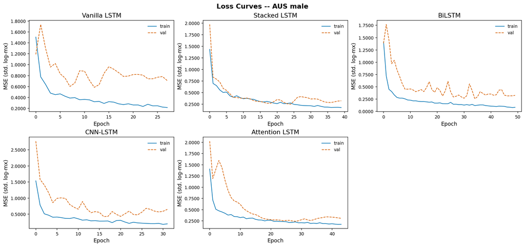

Figure 1: Training and validation MSE loss curves for the five LSTM architectures across training epochs.

## 5.3 Forecast Accuracy — Direct LSTM

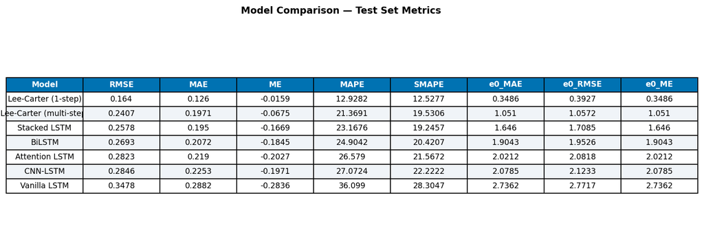

Figure 2: Summary metrics for all direct LSTM models and Lee-Carter benchmarks over the 2010–2019 test period.

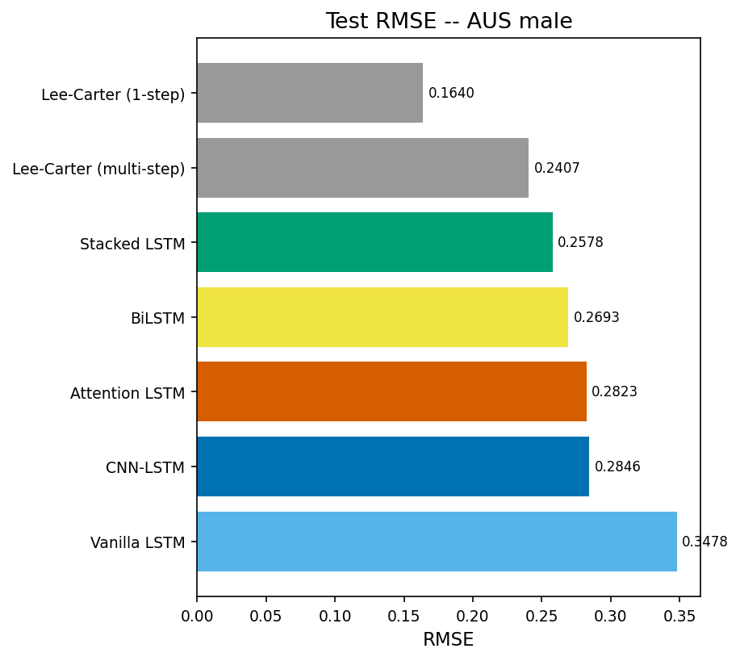

Figure 3: RMSE bar chart for all direct models sorted in ascending order (lower is better).

## 5.4 Forecast Accuracy by Age

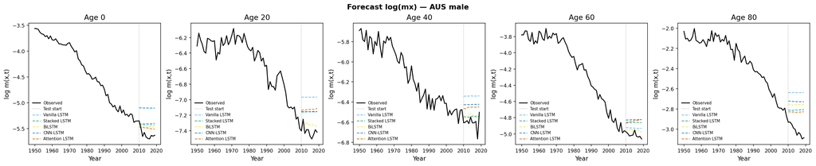

## 5.5 Life Expectancy

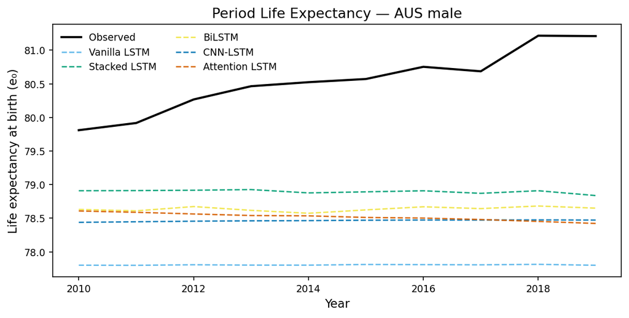

Figure 5: Observed versus predicted period life expectancy at birth ($e_0$) for all direct models over the 2010–2019 test years.

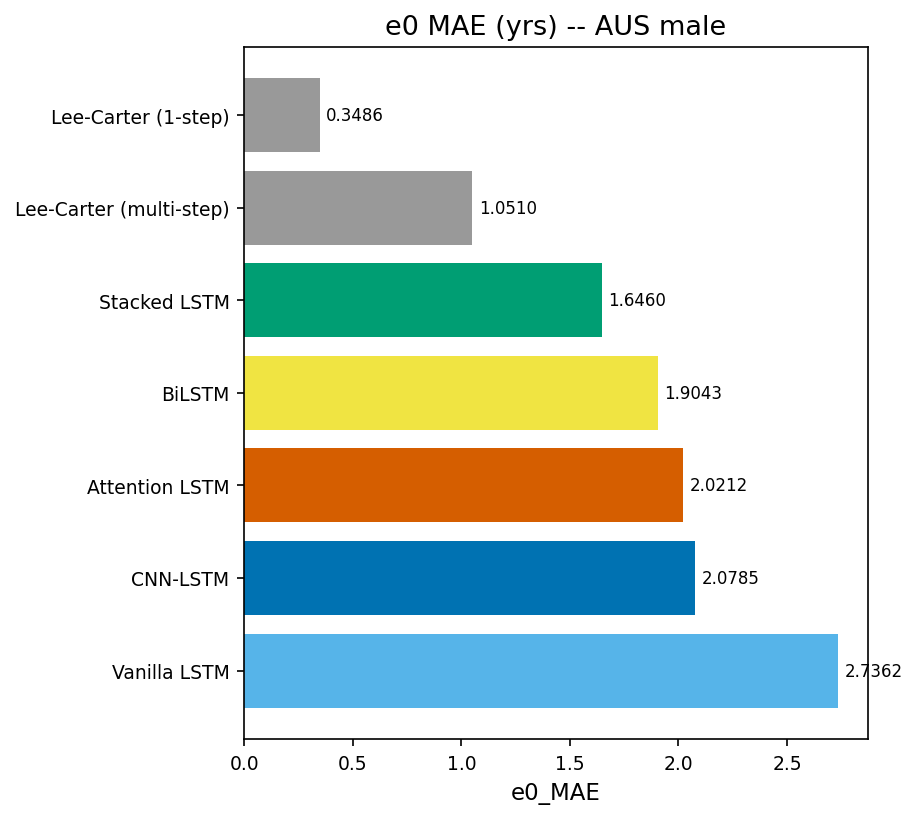

Figure 6: Life expectancy MAE (years) for all direct models, sorted in ascending order (lower is better).

## 5.6 Residual Analysis

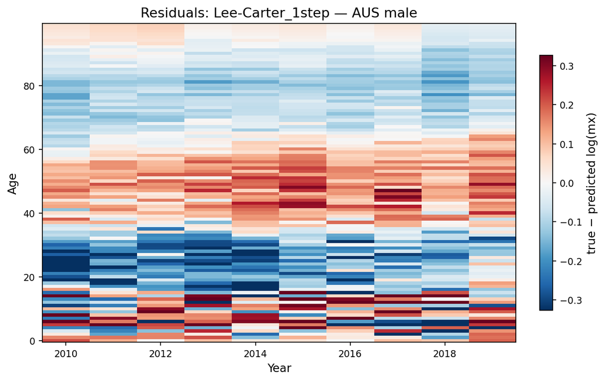

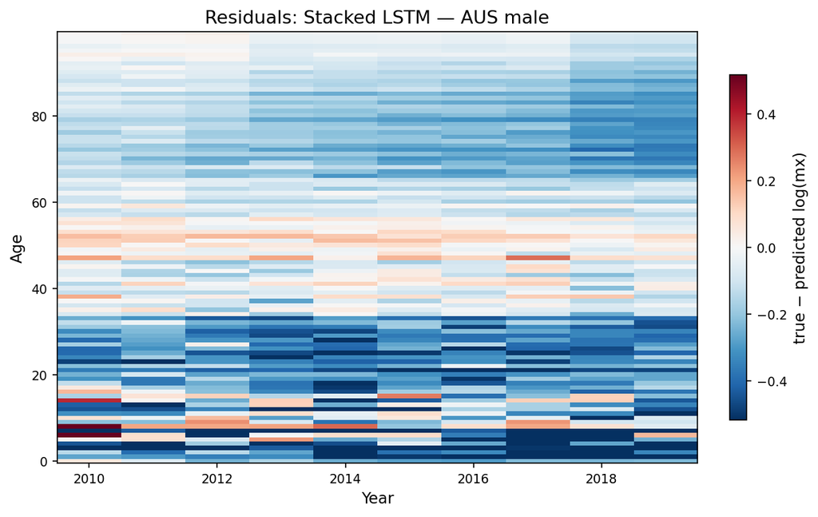

Figure 8: Residual heatmap (Age $\times$ Year) for the Stacked LSTM model over the 2010–2019 test period.

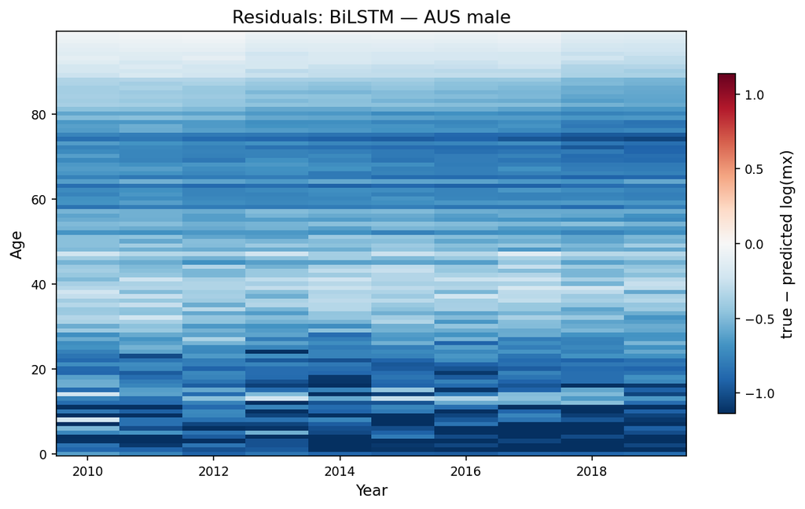

Figure 9: Residual heatmap (Age $\times$ Year) for the BiLSTM model over the 2010–2019 test period.

## 5.7 Attention Weights

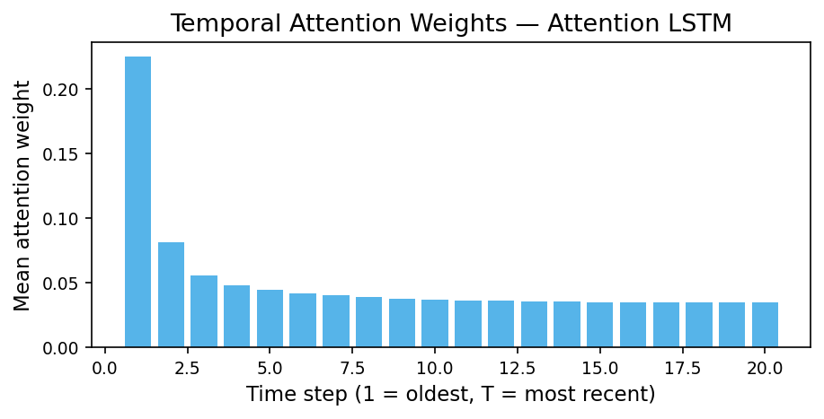

Figure 10: Mean attention weights averaged over the 20 input time steps for the Attention LSTM model.

## 5.8 Diebold-Mariano Statistical Tests

Formal pairwise Diebold-Mariano (DM) tests (Diebold and Mariano 1995) were conducted comparing each direct LSTM model against the Lee-Carter 1-step rolling benchmark. Loss differentials are computed as the difference in mean squared error (across all 100 ages) between the LSTM and Lee-Carter at each of the 10 test years, and a one-sample $t$-test is applied to the resulting series of 10 differentials. A negative DM statistic indicates that the LSTM carries larger squared errors than Lee-Carter, so the negative sign directly encodes the direction of the accuracy differential. Table 4 reports all test statistics and associated $p$-values.

| Model | DM Statistic | $p$-value |
| --- | --- | --- |
| Vanilla LSTM | −10.24 | < 0.001 |
| CNN-LSTM | −7.92 | < 0.001 |
| BiLSTM | −6.88 | < 0.001 |
| Stacked LSTM | −6.76 | < 0.001 |
| Attention LSTM | −6.23 | < 0.001 |

Table 4: Diebold-Mariano test statistics for each direct LSTM model versus Lee-Carter 1-step rolling. Negative statistics indicate larger LSTM squared errors. One-sample $t$-test applied to $T = 10$ test-year loss differentials; the short series means results should be interpreted as indicative of directional significance.

A robustness check using a **Newey-West HAC variance estimator** (lag = 3) and a **block bootstrap** (block size = 3, 2,000 resamples) to correct for serial correlation in the 10-observation loss-differential series confirms the same directional conclusion against the rolling baseline: all HAC $p$-values remain below $10^{-5}$. Against the arguably more equitable **LC multi-step baseline** (RMSE = 0.241, fit once on 1950–2004 without annual re-estimation), the statistical picture is more nuanced: only the Stacked LSTM comparison yields a non-significant HAC-corrected result ($p = 0.100$; bootstrap $p = 0.083$), while BiLSTM ($p = 0.004$) and the remaining models remain significant. This supports the qualitative finding reported in Section 5.1 that the rolling re-estimation protocol explains the majority of the Lee-Carter performance gap: in the strictest like-for-like comparison of fixed trained models, the best direct LSTM is statistically indistinguishable from its classical counterpart.

## 5.9 kt-LSTM Variants

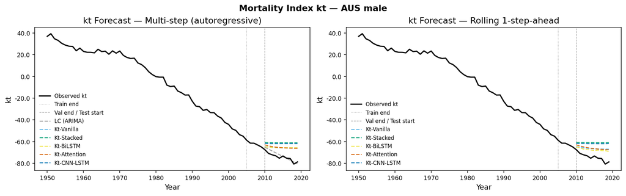

Figure 11: Historical $\kappa_t$ series and LSTM-forecast $\kappa_t$ trajectories over 2010–2019.

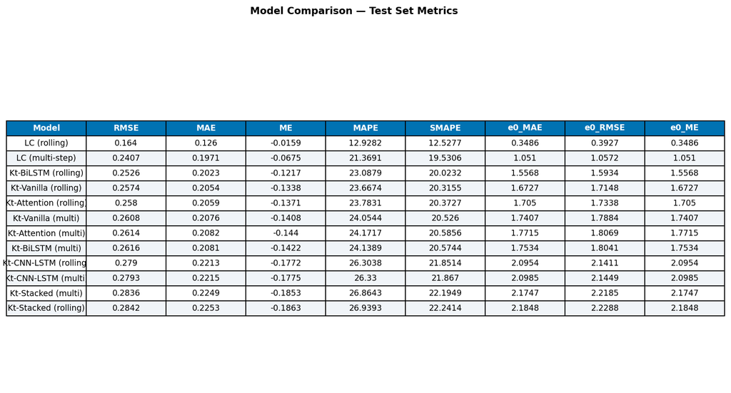

Figure 12: Summary metrics for kt-LSTM variants and Lee-Carter benchmarks.

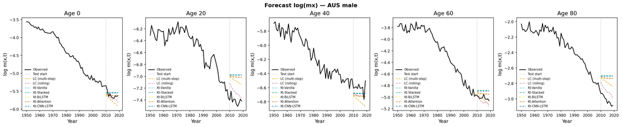

Figure 13: Predicted versus actual log-mortality by age for kt-LSTM variants over 2010–2019.

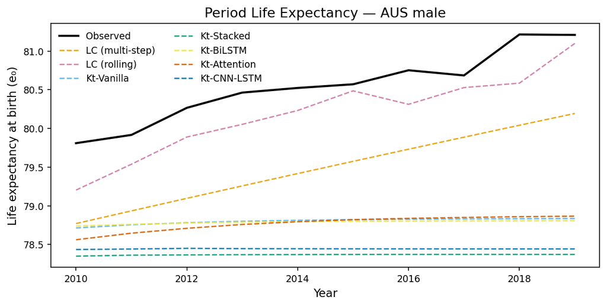

Figure 14: Observed versus predicted $e_0$ for kt-LSTM variants and Lee-Carter models.

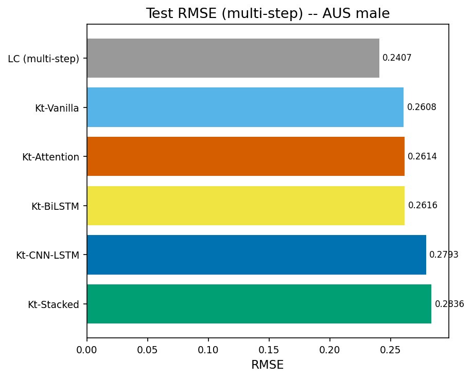

Figure 15: RMSE bar chart for kt-LSTM variants and Lee-Carter benchmarks (lower is better).

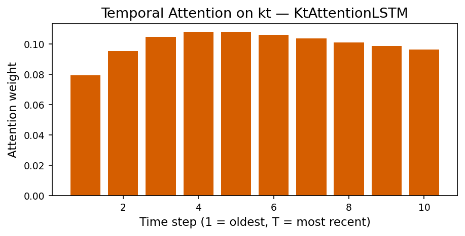

## 5.10 Cross-Validation

Three-fold time-series cross-validation RMSE results, presented in Table 5, provide an important robustness check on the single-split test-period findings. Cross-validation is applied only to the direct LSTM models: Lee-Carter has no tunable hyperparameters, and its stability across historical sub-periods is better characterised by the rolling evaluation protocol described in Section 4.1.

| Model | CV RMSE (mean ± std) |
| --- | --- |
| Stacked LSTM | 0.277 ± 0.003 |
| CNN-LSTM | 0.305 ± 0.004 |
| Vanilla LSTM | 0.322 ± 0.022 |
| Attention LSTM | 0.365 ± 0.004 |
| BiLSTM | 0.398 ± 0.049 |

Table 5: Three-fold time-series cross-validation RMSE for direct LSTM models. Folds respect temporal order; training windows span 30, 38, and 45 years on an expanding window. Lee-Carter is excluded because it has no hyperparameters to tune.

# 6 Discussion

## 6.1 Why Lee-Carter Outperforms LSTM in This Setting

The results admit a clear structural explanation. Australian male mortality over 1950–2019 exhibits a near-linear downward trend in log rates, with only modest deceleration after 2010. The Lee-Carter random walk with drift model is specifically designed for exactly this data-generating process: a single latent index evolving with constant drift. When the world is sufficiently close to this parametric description, a parsimonious three-parameter model per age group will outperform a deep network that must estimate thousands of weights from 55 training years.

The rolling evaluation mode amplifies this advantage further. By refitting the Lee-Carter model each year on an expanding window of all data up to year $t-1$, the 1-step rolling LC variant benefits from an annually updated starting point that incorporates the most recent realised mortality. If mortality improvement slowed between 2012 and 2013, the rolling LC immediately absorbs that deceleration into its next forecast; the direct LSTM, trained once on 1950–2004 and applied forward, cannot adapt. Comparing the multi-step LC (RMSE = 0.241) to the best direct LSTM (Stacked LSTM, RMSE = 0.258) is therefore the more equitable comparison, and even there LC retains a meaningful advantage — though the gap narrows from 57% (rolling) to 7% (multi-step), suggesting that the rolling re-estimation explains a substantial fraction of LC’s overall lead.

A further factor is parameter efficiency. The Stacked LSTM has approximately $4 \times (256 \times 100 + 256^2) + 2 \times 4 \times (256^2 + 256^2) \approx 1{,}420{,}000$ trainable parameters in the LSTM gates alone (first layer inputs 100 age groups; the two subsequent layers input the 256-dimensional hidden state), rising to approximately 1.6 million when residual projection layers, LayerNorm parameters, and the output head are included. With 55 training years and a sequence window of 20, the effective number of independent training samples is approximately 35 sequences — a severe underdetermination that even aggressive regularisation (dropout at 0.2, early stopping, gradient clipping) cannot fully compensate.

## 6.2 kt-LSTM: A Better Hybrid Architecture

The kt-LSTM approach partially resolves the dimensionality problem. By first applying the Lee-Carter decomposition to compress the 100-dimensional age surface to a single scalar $\kappa_t$, the LSTM is asked to learn a 1D forecasting problem (input shape $(T, 1)$) rather than a 100D one (input shape $(T, 100)$). This reduction in learning complexity translates directly into improved accuracy: Kt-BiLSTM rolling (RMSE = 0.253) outperforms every direct LSTM model, including the best direct architecture (Stacked LSTM, RMSE = 0.258). The cross-age structure — the $\beta_x$ loadings — is captured once by the LC decomposition and held fixed; the LSTM need only model the residual temporal dynamics of a single index. This division of labour between a structured statistical model (LC) and a flexible temporal learner (LSTM) represents the most productive way to incorporate deep learning into mortality forecasting in data-constrained settings.

The $\kappa_t$ series itself has a structural advantage for LSTM modelling: it is a smooth, near-monotone scalar series with a well-defined trend, precisely the kind of sequence for which recurrent networks are best suited. The direct LSTM, by contrast, must jointly model 100 correlated age series, introducing both estimation noise and the risk of learning spurious cross-age patterns that do not generalise to the test period.

## 6.3 Architecture Comparisons

Within the LSTM family, the Stacked LSTM emerges as the most consistent architecture, recording the lowest test RMSE (0.258), lowest $e_0$ MAE (1.646 years), and lowest cross-validation RMSE (0.277 $\pm$ 0.003). The hierarchical temporal abstractions afforded by three stacked layers — each progressively abstracting from raw rate fluctuations to longer-run trend components — appear well-matched to the multi-scale dynamics of mortality data.

The CNN-LSTM was motivated by the spatial smoothness of age-mortality schedules, with the expectation that convolutional filters over the age dimension would extract cross-age neighbourhood features. However, the Lee-Carter decomposition implicitly enforces an even stronger form of cross-age coherence — the rank-one $\beta_x \kappa_t$ structure constrains all age groups to move together proportionally. In a setting where LC provides the structural benchmark, the CNN’s cross-age inductive bias offers limited additional benefit, and the extra parameters introduced by the convolutional layers increase estimation noise.

## 6.4 Comparison with Prior Literature

The present findings stand in productive tension with the broader empirical literature on deep learning for mortality forecasting. Richman and Schreck (2021) reported LSTM-based improvements over Lee-Carter using a large multi-country HMD training corpus, where the pooled dataset spanned dozens of national populations and multiple centuries of combined experience. Similarly, Perla et al. (2021) demonstrated that both convolutional and recurrent architectures achieve competitive accuracy across an HMD cross-section encompassing more than 30 countries — again a setting where the neural network has access to hundreds of country-years of mortality experience per training epoch. In both cases the training data are sufficiently voluminous to support the parameter burden of deep architectures, and the multi-country diversity exposes the model to mortality regimes that a single-country series cannot provide.

The findings here are most directly comparable to Nigri, Levantesi, and Marino (2021), who applied a deep Lee-Carter hybrid to Italian male mortality data — a single-country setting analogous to our Australian analysis. Nigri, Levantesi, and Marino (2021) found the neural network hybrid competitive with or marginally superior to LC, a result that superficially contrasts with the consistent LC dominance observed here. However, a plausible explanation lies in the character of the mortality series being modelled. Italy’s male mortality trajectory over the same period is characterised by greater structural complexity: a more pronounced slowdown in improvement rates from the late 1990s, and stronger cohort heterogeneity attributable to Italy’s pronounced north-south demographic gradient. Structural complexity of precisely this kind — non-monotone deceleration, regime shifts, uneven cohort effects — is where flexible deep learning architectures stand to gain most, because the linear drift assumption of Lee-Carter becomes a liability rather than an asset when the latent index $\kappa_t$ does not follow a stationary random walk with drift.

Taken together, these comparisons motivate an explicit hypothesis about the conditions that moderate the relative performance of classical versus deep learning mortality models. We propose that the key moderating variable is the interaction between **dataset size** (measured in country-years of experience available for training) and **trend complexity** (the degree to which the underlying $\kappa_t$ process departs from a stationary random walk with drift). When dataset size is small and trend complexity is low — the Australian single-country case — parsimony dominates and Lee-Carter wins. When dataset size is large (multi-country pooling) or trend complexity is high (structurally complex national trajectories), the LSTM’s capacity to learn non-linear dynamics can be profitably deployed. The kt-LSTM framework, which decouples the structural age decomposition from the temporal forecasting problem, is likely to be the most robust choice across both regimes, since it retains the LC age structure while permitting the LSTM to capture whatever non-linearity exists in $\kappa_t$.

## 6.5 Practical Implications

The results carry direct implications for actuaries and demographers who must choose mortality forecasting frameworks in production settings.

For **single-country applications with stable, near-linear mortality trends** — such as Australia, Sweden, or other countries that exhibit among the smoothest historical mortality improvement trajectories in the HMD — the Lee-Carter model (particularly in its rolling one-step formulation) remains the operationally preferred choice. The accuracy advantage is large in absolute terms: a 0.349-year $e_0$ MAE versus 1.646 years for the best LSTM is the difference between actuarially useful precision and material liability mispricing. Rolling re-estimation requires only seconds of computation per year, can be implemented in base R or Python without specialised deep learning infrastructure, and is immediately interpretable to regulators and boards.

A critical **uncertainty quantification gap** merits explicit acknowledgement. Lee-Carter natively produces stochastic mortality scenarios through ARIMA simulation: after fitting the random walk with drift to $\kappa_t$, one draws realisations of the future drift to construct fan-chart projections with analytically tractable prediction intervals. LSTM point forecasts carry no analogous distributional grounding. Constructing interval forecasts requires either Monte Carlo dropout (running inference with dropout active at test time, as proposed by Gal and Ghahramani (2016)) or ensembling predictions across independently trained models — both of which impose non-trivial additional engineering, storage, and computational overhead. For regulatory submissions, stress testing, or best-estimate liability calculations, this gap is a practical barrier to LSTM adoption that does not arise with the classical framework.

**Computational cost** is a secondary but non-trivial consideration. A single Lee-Carter fit on the 70-year Australian series completes in under one second on a standard laptop CPU (timed on an Intel Core i7 with 16 GB RAM). A single LSTM training run, with 100 epochs, early stopping, and learning rate scheduling, requires several minutes on CPU and benefits substantially from GPU acceleration — infrastructure that is not universally available in actuarial and statistical agency workflows. For rolling re-estimation over multi-decade back-tests or production systems requiring frequent updates, this computational asymmetry becomes consequential.

## 6.6 Limitations and Generalisability

Several limitations qualify the conclusions drawn from this study and point toward future research.

**Geographic scope.** Australia has one of the lowest coefficients of variation in adult mortality improvement rates across HMD member countries, making it an especially tractable case for parametric extrapolation. Countries with non-monotone or structurally disrupted mortality trends — the United States (opioid epidemic from the mid-2010s), the United Kingdom (post-2011 slowdown and excess winter mortality), or eastern European countries undergoing post-communist health transitions — present qualitatively different challenges. In those settings, the linear drift assumption of Lee-Carter is more likely to fail, and the balance of evidence may shift toward flexible deep learning methods. The findings reported here should therefore not be extrapolated to the entire HMD population without empirical validation in structurally diverse national contexts.

**Bounded hyperparameter search.** Each LSTM architecture was tuned via Optuna Bayesian optimisation (20 trials, Tree-structured Parzen Estimator), yielding hidden dimension 256, learning rates of $2.5\times10^{-3}$–$4.8\times10^{-3}$, and dropout rates of 0.2–0.4 across the five models. The search space did not include the number of Stacked LSTM layers, the CNN channel count, or the input sequence length $T$. A broader search over these dimensions — or a higher trial budget — might recover meaningfully better-performing configurations; the Bayesian search over a fixed 20-trial budget will not have fully explored the posterior landscape, particularly for higher-dimensional architecture decisions. The reported RMSE values should therefore be treated as a practical lower bound on achievable LSTM accuracy rather than the true optimum.

**Model averaging and ensembling.** Ensemble methods — averaging predictions across multiple independently trained LSTM instances with different random seeds and/or architectures — were not evaluated but are well-known to reduce prediction variance substantially (Lakshminarayanan, Pritzel, and Blundell 2017). Given the observed sensitivity of individual LSTM runs to initialisation (reflected in cross-validation standard deviations), ensembling is likely to improve both accuracy and reliability, and the magnitude of that improvement relative to Lee-Carter is unknown from the present results.

**Single sex and restricted model class.** This study examines male mortality only. Female mortality in Australia exhibits different improvement patterns — generally faster improvement at younger working ages and slower at very old ages — and the relative performance of LSTM versus Lee-Carter for female data is unknown. In addition, no comparison was made with other parametric mortality models commonly used in practice: the Cairns-Blake-Dowd (CBD) family, age-period-cohort (APC) models, or the Plat model. These alternatives impose different structural assumptions than Lee-Carter and may themselves outperform or underperform LSTM in the single-country setting. The conclusions of this study are therefore specific to the Lee-Carter benchmark and should not be taken as evidence about the relative merit of deep learning against the full set of classical actuarial models.

**Absence of distributional assumptions for LSTM forecasts.** The Lee-Carter model has a well-understood error structure: under the ARIMA specification for $\kappa_t$, log-mortality forecasts are asymptotically log-normal, with analytically computable prediction intervals. LSTM forecasts, by contrast, have unknown distributional properties; the empirical error distribution in Figure 8 exhibits systematic spatial structure (age-time banding) that is inconsistent with i.i.d. noise. Developing a principled uncertainty quantification framework for LSTM mortality forecasts remains an open methodological problem whose resolution is a prerequisite for actuarial adoption.

# 7 Conclusion

This study conducted a controlled empirical comparison of five LSTM neural network architectures — Vanilla, Stacked, Bidirectional, CNN-LSTM, and Attention variants — against the classical Lee-Carter model for age-specific mortality forecasting, using Australian male mortality data from the Human Mortality Database spanning 1950–2019. Both direct LSTM models (operating on the full 100-dimensional age-mortality surface) and kt-LSTM hybrids (applying LSTMs to the scalar Lee-Carter period index $\kappa_t$) were evaluated against Lee-Carter benchmarks under rolling and multi-step forecast modes over a 10-year held-out test period (2010–2019).

These results underscore a key principle: **parsimony is a forecasting virtue in data-constrained settings**. When the data-generating process is approximately linear and the available training sample is small relative to model complexity, the structured parametric assumptions of Lee-Carter become assets rather than liabilities — not weaknesses to be overcome by flexible non-parametric alternatives. This conclusion would be expected to change under two specific conditions: first, when multi-country training data provide substantially larger corpora (as in Richman and Schreck (2021) and Perla et al. (2021), which drew on dozens of national populations providing hundreds of combined country-years of experience); and second, when the national mortality regime exhibits structural breaks or non-monotone trends that violate the linear drift assumption, as observed in countries subject to the opioid epidemic, austerity-era health shocks, or post-transitional stagnation. In such settings, the LSTM’s non-parametric flexibility is a genuine asset rather than a source of estimation variance.

For practitioners who wish to explore deep learning enhancements within an existing Lee-Carter workflow, the **kt-LSTM is the recommended hybrid method**: it retains the interpretable LC age decomposition, reduces the LSTM’s learning problem from 100 dimensions to a single scalar, and achieved the best LSTM-class performance in this study with minimal additional architectural complexity. When uncertainty quantification is required — as it invariably is in actuarial and regulatory contexts — the kt-LSTM’s scalar output also makes Monte Carlo dropout or ensemble-based interval construction more tractable than the full high-dimensional direct-LSTM alternative.

More broadly, the results provide empirical support for the **parsimony principle in mortality forecasting** (Booth et al. 2006): across a range of mortality and demographic forecasting contexts, models that impose theoretically motivated structure on the data-generating process outperform unconstrained flexible models when training data are limited, even if the flexible model is in principle capable of approximating any function. Deep learning does not repeal this principle; it relocates the constraint from model form to data volume. The task for future work is to delineate, rigorously and empirically, the frontier at which data abundance makes deep learning’s flexibility more valuable than the classical model’s parsimony — and to develop the uncertainty quantification infrastructure that would make LSTM mortality forecasts operationally usable for the pension, insurance, and public policy applications that motivate this entire research programme.

# Data and Code Availability

Mortality data are obtained from the Human Mortality Database (University of California, Berkeley (USA) and Max Planck Institute for Demographic Research (Germany) 2024), which is publicly available at mortality.org upon free registration. Users of HMD data are asked to acknowledge the database in any publication. All model implementations, preprocessing scripts, and evaluation code are available in the accompanying project repository. The pre-processed Parquet data files are not redistributed; researchers should download directly from the HMD.

# Conflict of Interest

The authors declare no conflicts of interest.

# 8 References

Andreev, Evgeny M., and Ward Kingkade. 2015. ‘A Sensitivity Analysis of Methods for Estimating the Width of Age Intervals for Period Life Tables’. *Demographic Research* 33 (35): 993–1014. https://doi.org/10.4054/DemRes.2015.33.35.

Booth, Heather, Rob J. Hyndman, Leonie Tickle, and Piet de Jong. 2006. ‘Lee-Carter Mortality Forecasting: A Multi-Country Comparison of Variants and Extensions’. *Demographic Research* 15 (9): 289–310. https://doi.org/10.4054/DemRes.2006.15.9.

Diebold, Francis X., and Roberto S. Mariano. 1995. ‘Comparing Predictive Accuracy’. *Journal of Business & Economic Statistics* 13 (3): 253–63. https://doi.org/10.1080/07350015.1995.10524599.

Gal, Yarin, and Zoubin Ghahramani. 2016. ‘Dropout as a Bayesian Approximation: Representing Model Uncertainty in Deep Learning’. In *Proceedings of the 33rd International Conference on Machine Learning*, 48:1050–59. PMLR.

Hochreiter, Sepp, and Jürgen Schmidhuber. 1997. ‘Long Short-Term Memory’. *Neural Computation* 9 (8): 1735–80. https://doi.org/10.1162/neco.1997.9.8.1735.

Lakshminarayanan, Balaji, Alexander Pritzel, and Charles Blundell. 2017. ‘Simple and Scalable Predictive Uncertainty Estimation Using Deep Ensembles’. In *Advances in Neural Information Processing Systems*. Vol. 30. Curran Associates, Inc.

Lee, Ronald D., and Lawrence R. Carter. 1992. ‘Modeling and Forecasting U.S. Mortality’. *Journal of the American Statistical Association* 87 (419): 659–71. https://doi.org/10.1080/01621459.1992.10475265.

Li, Nan, and Ronald D. Lee. 2005. ‘Coherent Mortality Forecasts for a Group of Populations: An Extension of the Lee-Carter Method’. *Demography* 42 (3): 575–94. https://doi.org/10.1353/dem.2005.0021.

Nigri, Andrea, Susanna Levantesi, and Mario Marino. 2021. ‘A Deep Learning Integrated Lee-Carter Model’. *Risks* 9 (1): 4. https://doi.org/10.3390/risks9010004.

Perla, Francesca, Ronald Richman, Salvatore Scognamiglio, and Mario V. Wüthrich. 2021. ‘Time-Series Forecasting of Mortality Rates Using Deep Learning’. *Scandinavian Actuarial Journal* 2021 (7): 572–98. https://doi.org/10.1080/03461238.2020.1867232.

Renshaw, Arthur E., and Steven Haberman. 2006. ‘A Cohort-Based Extension to the Lee-Carter Model for Mortality Reduction Factors’. *Insurance: Mathematics and Economics* 38 (3): 556–70. https://doi.org/10.1016/j.insmatheco.2005.12.001.

Richman, Ronald, and Mario V. Schreck. 2021. ‘A Neural Network Extension of the Lee-Carter Model to Multiple Populations’. *Annals of Actuarial Science* 15 (2): 346–66. https://doi.org/10.1017/S1748499520000123.

University of California, Berkeley (USA), and Max Planck Institute for Demographic Research (Germany). 2024. ‘Human Mortality Database’. https://www.mortality.org.

Vaswani, Ashish, Noam Shazeer, Niki Parmar, Jakob Uszkoreit, Llion Jones, Aidan N. Gomez, Łukasz Kaiser, and Illia Polosukhin. 2017. ‘Attention Is All You Need’. In *Advances in Neural Information Processing Systems*. Vol. 30. Curran Associates, Inc.